# SOCIAL NETWORKS ANALYSIS (MBD-EN-BL2020J-1_32R220_387064)

Alberto I., Daniel R., Iman H., Juan Pedro B., Pablo B., Vania M.

# Assignment Description and Deliverables

Practical social network analysis analysis of a music related dataset. The assignment includes the following deliverables: 1) Interactive Shiny App. GROUP C uses this interactive app for its final presentation with the aim to have a more interactive and fun approach with the class (https://juanbretti.shinyapps.io/social/). 2) HTML report generated directly from this .Rmd file. 3) An insightful .ppt file to summarize the overall work and key information.

# Analysis. Steps completed

# Dataset Description

The selected dataset comes from the following source: https://www.allmusic.com/ This source includes detailed music referred information with details over artists and songs. Specifically at this site the following information can be retrieved:

- Artists.
- Genres & Styles.
- Music Themes.
- Music ratings.
- Recording Details & Types.
- Album Moods.
- Album Themes.

Downloaded datasets: https://www.kaggle.com/chuninghe/music-artistsinfluence-data that relate to the previous referred site.

Specifically, in this exercise GROUP C used the following data:

1. Artists Details (data_by_artist.csv). Includes in total 5854 artists and a total of 14 relevant features.
- danceability
- energy
- valence
- tempo
- loudness
- mode
- key
- acousticness
- instrumentalness
- liveness
- speechiness
- duration_ms
- popularity
- count
2. Music/ Songs related information (full_music_data.csv). Includes in total 98340 records related to artist songs and 16 relevant features. These features describe the characteristics of each of the songs.
- danceability
- energy
- valence
- tempo
- loudness
- mode
- key
- acousticness
- instrumentalness
- liveness
- speechiness
- explicit
- duration_ms
- popularity
- year
- release_date

The representation of an artist is built out of the songs he/she released in the past. In that way, both songs and artists can share an even vectorial space where both can be related. This is quite useful to assess proximity among different artists and songs. Proximity is defined by pure music style from the songs from one artist to another.

3. Influence data among the different artists (influence_data.csv). This dataset includes relationship/ influence between the different artists and includes 42770 records with the following features:
- influencer_id
- influencer_name
- influencer_main_genre
- influencer_active_start
- follower_id
- follower_name
- follower_main_genre
- follower_active_start

This last set helps stablish the relationships in a graph or edges between the different artists.

# Environment

## Load libraries

This step loads the main libraries used in the exercise.

```r
#install.packages("tidyverse")
#install.packages("igraph")
#install.packages("caret")
#install.packages("PerformanceAnalytics")
#install.packages("networkD3")

library(tidyverse)
library(igraph)
library(caret)
library(PerformanceAnalytics)
library(networkD3)
```

```r
theme_set(theme_minimal(base_size = 20))
```

## Load data

Load up of the data as described at the start of this file.

```r
data_music <- read_csv('data/full_music_data.csv')
data_influence <- read_csv('data/influence_data.csv')
data_artist <- read_csv('data/data_by_artist.csv')
```

In the next steps there is a minor processing of the dataset. Data from the source is already curated and thus the processing itself is minor.

Reformat of the dataframes.

```r
data_influence <- data_influence %>%
  mutate(follower_main_genre = str_remove_all(follower_main_genre, ';'))

artist_genre <- data_influence %>%
  select(`follower_name`, `follower_main_genre`) %>%
  unique() %>%
  rename(`artist_names`=`follower_name`, `main_genre`=`follower_main_genre`)

data_music_genre <- data_music %>%
  transform(artists_id = strsplit(str_trim(str_remove_all(artists_id, '[\\[\\]]'), side='both'), ","),
            artist_names = strsplit(str_trim(str_remove_all(artist_names, '[\\[\\]]'), side='both'), ",")) %>%
  unnest(artist_names) %>%
  mutate(artist_names = gsub('^.|.$', '', artist_names)) %>%
  inner_join(artist_genre, by="artist_names")
```

Unknown artist identification.

```r
unique_a <- unique(data_artist['artist_id'])
unique_b <- unique(data_influence['influencer_id'])
unique_c <- unique(data_influence['follower_id'])

table(unlist(unique_b) %in% unlist(unique_a))
```

```
##
## TRUE
## 3774
```

```r
table(unlist(unique_c) %in% unlist(unique_a))
```

```
##
## FALSE  TRUE
##     1  5045
```

The id for this artist:

```r
unknown_artist <- unique_c[!(unlist(unique_c) %in% unlist(unique_a)),]
```

## Calculate `PCA`

In this chapter PCA is applied to get a representation via 3 principal components for each of the artists. a) Scaling is required prior to PCA. b) PCAs are saved as features in data_artist dataframe. c) Generated a dataframe where each influence record has a vectorial representation of both followers and influencers. d) Calculation of weights of relationships by means of Eucledian distance of the vectors between influencers and followers.

```r
# colnames(data_artist)
columns_to_normalize <- c("danceability", "energy", "valence", "tempo", "loudness", "mode", "key", "acousticness", "instrumentalness", "liveness", "speechiness", "duration_ms", "popularity", "count")

data <- data_artist[, columns_to_normalize]
tranformation_1 <- preProcess(data, method=c("scale", "pca"), pcaComp=3)
data_artist$PC1 <- predict(tranformation_1, data)[['PC1']]
data_artist$PC2 <- predict(tranformation_1, data)[['PC2']]
data_artist$PC3 <- predict(tranformation_1, data)[['PC3']]

data_influence_transformed <- data_influence %>%
  inner_join(data_artist[, c('artist_id', 'PC1', 'PC2', 'PC3')], by = c("influencer_id" = "artist_id")) %>%
  inner_join(data_artist[, c('artist_id', 'PC1', 'PC2', 'PC3')], by = c("follower_id" = "artist_id"), suffix = c("_influencer", "_follower")) %>%
  rowwise() %>%
  mutate(`weight` = dist(matrix(c(`PC1_influencer`, `PC1_follower`, `PC2_influencer`, `PC2_follower`, `PC3_influencer`, `PC3_follower`), nrow = 2)))
```

```r
vars <- apply(tranformation_1$rotation, 2, var)
vars/sum(vars)
```

```
##       PC1       PC2       PC3
## 0.3196879 0.3516645 0.3286476
```

```r
pc1 <- sum(tranformation_1$rotation[,1])
pc2 <- sum(tranformation_1$rotation[,2])
pc3 <- sum(tranformation_1$rotation[,3])

pc1/sum(pc1+pc2+pc3)
```

```
## [1] 9.368435
```

## Create the graph

In this case the graph is created and details over nodes and edges are retrieved.

```r
data_influence_edges <- data_influence_transformed %>%
  rename(from=influencer_id, to=follower_id) %>%
  relocate(from, to, weight)

data_artist_vertices <- data_artist %>%
  rename(name=artist_name) %>%
  relocate(artist_id)

g <- graph_from_data_frame(d=data_influence_edges, vertices=data_artist_vertices, directed=TRUE)
class(g)
```

```
## [1] "igraph"
```

```r
ecount(g)
```

```
## [1] 42752
```

```r
vcount(g)
```

```
## [1] 5854
```

```r
g
```

```
## IGRAPH 3362f20 DNW- 5854 42752 --
## + attr: name (v/c), danceability (v/n), energy (v/n), valence (v/n),
## | tempo (v/n), loudness (v/n), mode (v/n), key (v/n), acousticness
## | (v/n), instrumentalness (v/n), liveness (v/n), speechiness (v/n),
## | duration_ms (v/n), popularity (v/n), count (v/n), PC1 (v/n), PC2
## | (v/n), PC3 (v/n), weight (e/n), influencer_name (e/c),
## | influencer_main_genre (e/c), influencer_active_start (e/n),
## | follower_name (e/c), follower_main_genre (e/c), follower_active_start
## | (e/n), PC1_influencer (e/n), PC2_influencer (e/n), PC3_influencer
## | (e/n), PC1_follower (e/n), PC2_follower (e/n), PC3_follower (e/n)
## + edges from 3362f20 (vertex names):
```

The description of an igraph object starts with up to four letters, in our case three:

1. D for a directed graph.
2. N for a named graph (where nodes have a name attribute).
3. W for a weighted graph (where edges have a weight attribute): when each connection does not have the same importance.

The two numbers that follow (5854 42752) refer to the number of nodes and edges in the graph. The description also lists node & edge attributes. * (v/c) - vertex-level character attribute * (v/n) - vertex-level numeric attribute * (e/n) - edge-level numeric attribute * (e/n) - edge-level character attribute

```r
# https://stackoverflow.com/questions/44892923/how-to-increase-length-of-edges-when-plotting-a-graph-in-r
# https://stackoverflow.com/questions/32012080/changing-the-spacing-between-vertices-in-igraph-in-r
# test.layout <- layout_(g, with_dh(weight.edge.lengths = edge_density(g)/1000))
# plot(g, layout = test.layout)
# plot(g)
```

# EDA

In this EDA step ggplot is used to generate a series of insightful charts: ## Duration evolution a) Song duration over time per genre. b) Song duration over time.

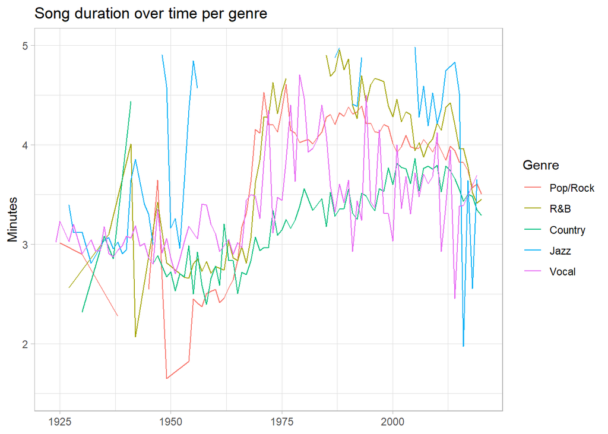

```r
top_ <- 5

sorted_music_genre <- data_music_genre %>%
  group_by(`main_genre`) %>%
  tally() %>%
  arrange(desc(n)) %>%
  select(`main_genre`) %>%
  unlist(use.names=FALSE)

data_music_genre %>%
  mutate(main_genre = factor(main_genre, levels=sorted_music_genre)) %>%
  filter(main_genre %in% sorted_music_genre[1:top_]) %>%
  group_by(`year`, `main_genre`) %>%
  summarise(mean=mean(duration_ms)/1000/60) %>%
  ggplot(aes(x=`year`, y=`mean`, color=`main_genre`)) +
  geom_line() +
  ylim(c(1.5, 5)) +
  labs(title='Song duration over time per genre', x=NULL, y='Minutes', color='Genre')+
  theme_light()
```

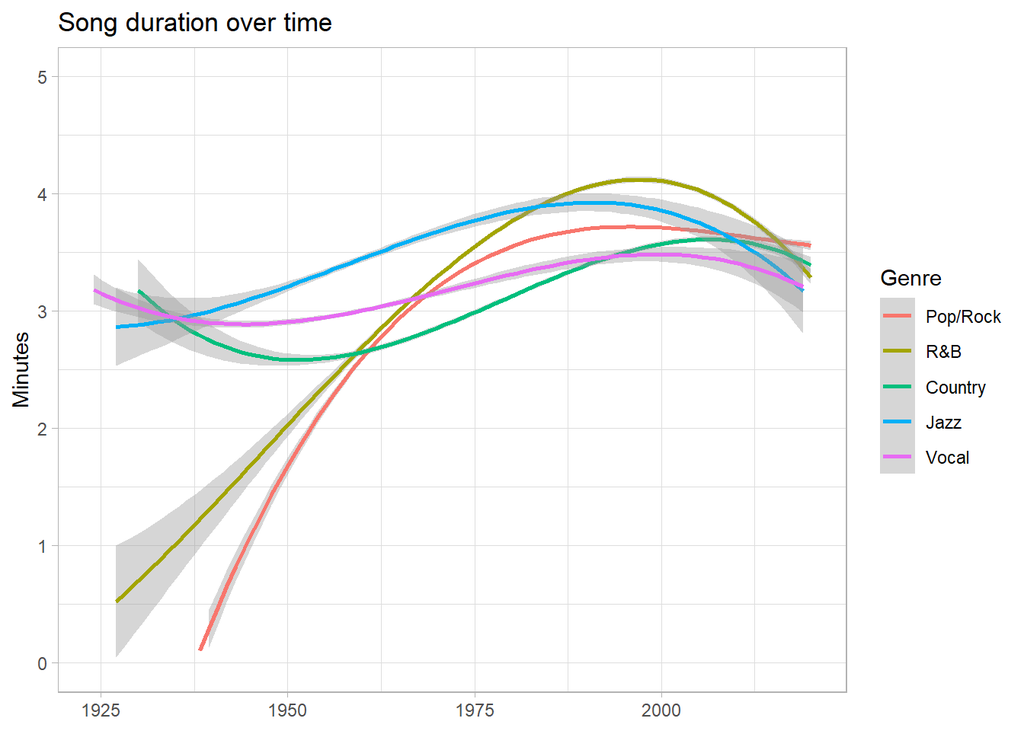

```r
data_music_genre %>%
  mutate(main_genre = factor(main_genre, levels=sorted_music_genre)) %>%
  filter(main_genre %in% sorted_music_genre[1:top_]) %>%
  ggplot(aes(x=`year`, y=`duration_ms`/1000/60)) +
  geom_smooth(aes(color=`main_genre`), method="lm", formula=y~poly(x, 3, raw=TRUE)) +
  ylim(c(0, 5)) +
  labs(title='Song duration over time', x=NULL, y='Minutes', color='Genre') +
  theme_light()
```

## Tempo evolution

3. Song tempo over time.

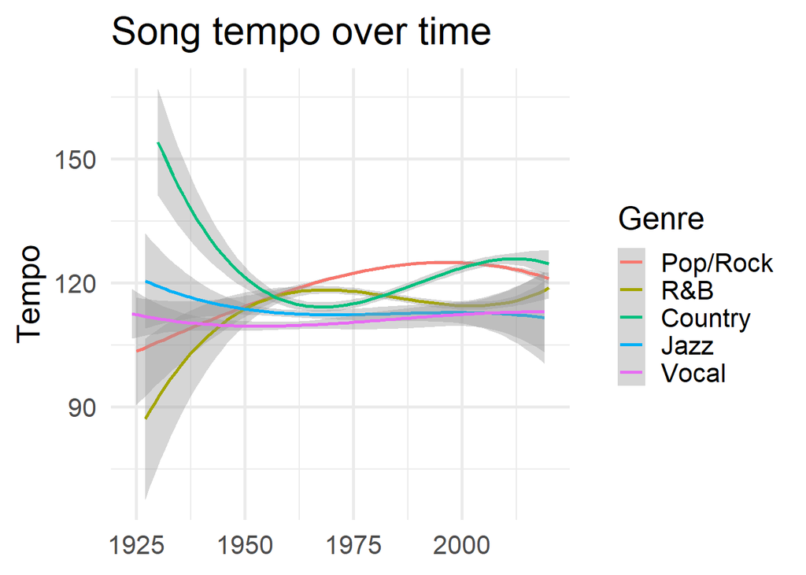

```r
data_music_genre %>%
  mutate(main_genre = factor(main_genre, levels=sorted_music_genre)) %>%
  filter(main_genre %in% sorted_music_genre[1:top_]) %>%
  ggplot(aes(x=`year`, y=`tempo`)) +
  geom_smooth(aes(color=`main_genre`), method="lm", formula=y~poly(x, 3, raw=TRUE)) +
  # ylim(c(0, 5)) +
  labs(title='Song tempo over time', x=NULL, y='Tempo', color='Genre')
```

## Top influencer artists

3. Top influencer artists.
4. Top influencer artists by genre.

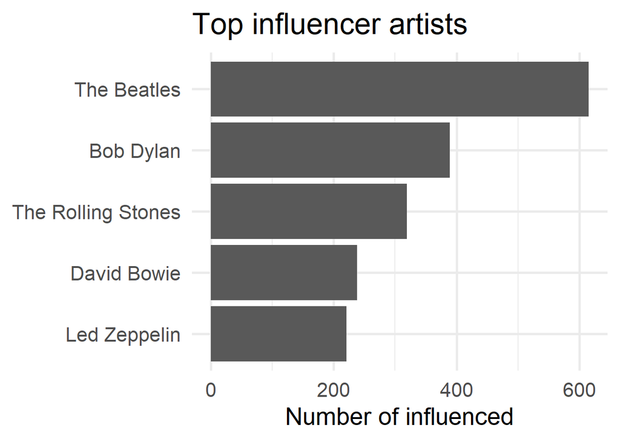

```r
top_influencers_ <- 5

data_influence_sorted <- data_influence %>%
  group_by(`influencer_name`) %>%
  tally() %>%
  arrange(desc(n)) %>%
  select(`influencer_name`) %>%
  unlist(use.names=FALSE)

data_influence %>%
  mutate(influencer_name = factor(influencer_name, levels=data_influence_sorted)) %>%
  dplyr::filter(influencer_name %in% data_influence_sorted[1:top_]) %>%
  group_by(`influencer_name`) %>%
  tally() %>%
  ggplot(aes(x=`influencer_name`, y=`n`)) +
  geom_col() +
  coord_flip() +
  scale_x_discrete(limits = rev) +
  labs(title='Top influencer artists', x=NULL, y='Number of influenced')
```

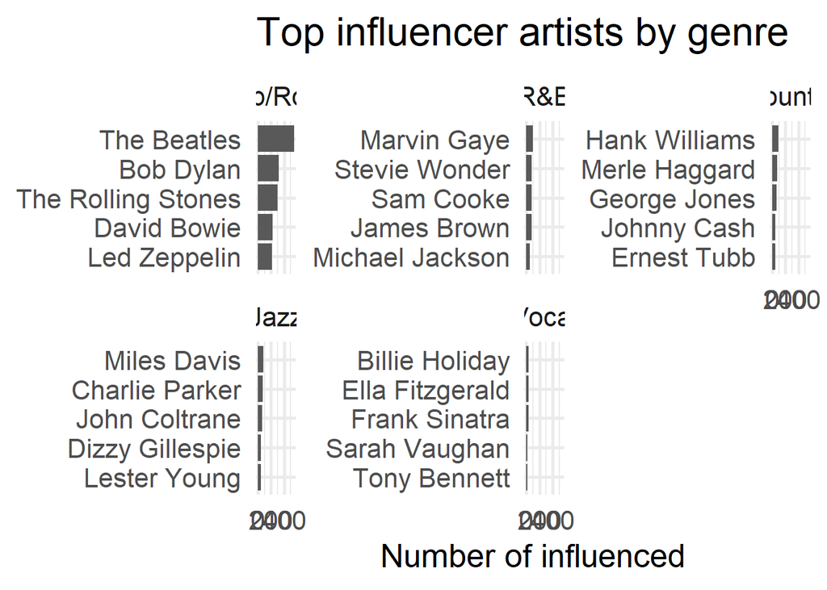

```r
data_influence %>%
  mutate(follower_main_genre = factor(follower_main_genre, levels=sorted_music_genre)) %>%
  filter(follower_main_genre %in% sorted_music_genre[1:top_]) %>%
  group_by(`follower_main_genre`, `influencer_name`) %>%
  tally() %>%
  arrange(desc(n)) %>%
  slice(1:top_influencers_) %>%
  ggplot(aes(x=reorder(`influencer_name`, -n, sum), y=`n`)) +
  geom_bar(stat = "identity") +
  coord_flip() +
  scale_x_discrete(limits = rev) +
  facet_wrap(`follower_main_genre` ~ ., scales="free_y") +
  labs(title='Top influencer artists by genre', x=NULL, y='Number of influenced')
```

## Source of inspiration by genre

5. Source of inspiration by genre

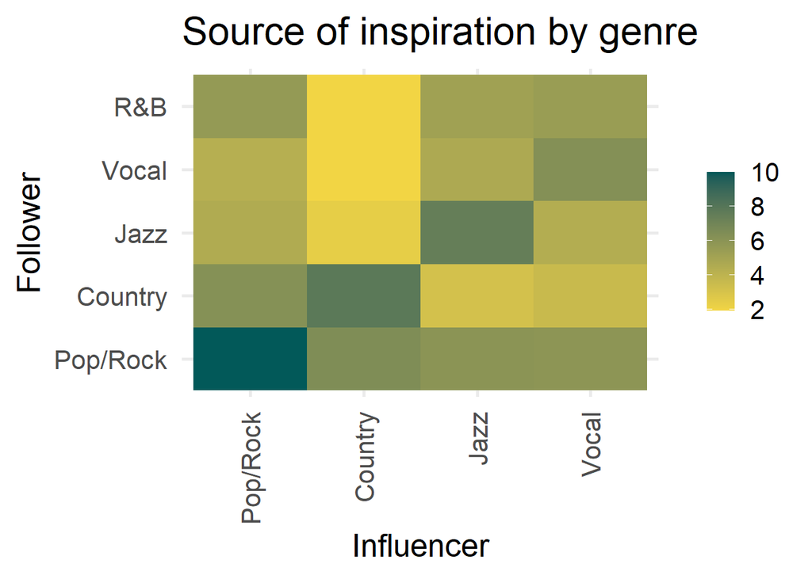

```r
data_influence %>%
  mutate(influencer_main_genre = factor(influencer_main_genre, levels=sorted_music_genre),
         follower_main_genre = factor(follower_main_genre, levels=sorted_music_genre)) %>%
  filter(influencer_main_genre %in% sorted_music_genre[1:top_], follower_main_genre %in% sorted_music_genre[1:top_]) %>%
  group_by(`influencer_main_genre`, `follower_main_genre`) %>%
  tally() %>%
  ggplot(aes(x=reorder(`influencer_main_genre`, -n, sum), y=reorder(`follower_main_genre`, -n, sum), fill=log(`n`))) +
  geom_tile() +
  scale_x_discrete(guide = guide_axis(angle = 90)) +
  labs(title='Source of inspiration by genre', x='Influencer', y='Follower', fill=NULL) +
  scale_fill_gradient(low="#F2D544", high="#025959")
```

# Description

## Order (number of vertices)

Used to count the number of vertices in a network https://igraph.org/r/doc/gorder.html

```r
gorder(g)
```

```
## [1] 5854
```

## Size of the graph (number of edges)

Used to count the number of edges in a network https://igraph.org/r/doc/gsize.html

```r
gsize(g)
```

```
## [1] 42752
```

## Degree distribution

The degree of a vertex is its most basic structural property, the number of its adjacent edges. Understood in this cases as the number of adjacent artists to a certain artist.

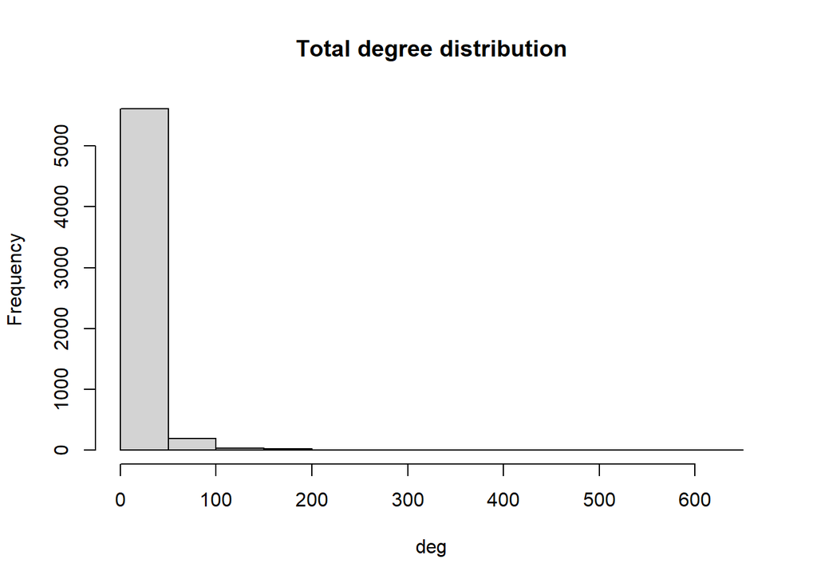

```r
deg <- degree(g, mode="all", loop=FALSE)
hist(deg, main='Total degree distribution')
```

## Degree description

Summary calculation for degree distribution. As seen this is quite skewed.

```r
summary(deg)
```

```
##    Min. 1st Qu.  Median    Mean 3rd Qu.    Max.
##    0.00    3.00    8.00   14.61   19.00  645.00
```

## Network Diameter and Average Path Length

Calculation for network diameter.

```r
diameter(g)
```

```
## [1] 81.9641
```

## Average path length of the graph

Calculation for network path length.

```r
mean_distance(g)
```

```
## [1] 6.164166
```

## Shortest paths between vertices

Distances calculates the length of all the shortest paths from or to the vertices in the network. shortest_paths calculates one shortest path (the path itself, and not just its length) from or to the given vertex.

```r
distance_table(g, directed = TRUE)
```

```
## $res
##  [1]   42752  355606 1156190 1435534 1003460  622708  426699  313833  255328
## [10]  219606  185560  164921  150942  126967  100522   74709   51319   35473
## [19]   23693   13941    7985    4451    2137     939     446     193      60
## [28]      11       1
##
## $unconnected
## [1] 27487476
```

## Centrality Measurements

In the case of `closeness`, there is a *warning* while having a disconnected graph:  
`closeness centrality is not well-defined for disconnected graphs`  
This can be saved, by finding the biggest subgraph, and only calculate the `closeness` of that.

```r
# https://stackoverflow.com/a/55891333/3780957
g_components <- components(g, mode="strong")

biggest_component <- which.max(g_components$csize)
g_main <- induced_subgraph(g, which(g_components$membership == biggest_component))
cl <- closeness(g_main, normalized=TRUE)
head(sort(cl, decreasing=TRUE), 5)
```

```
##  Jackie Wilson    James Brown   The Drifters Charlie Parker     Jimmy Reed
##      0.1501858      0.1497198      0.1485326      0.1371876      0.1356797
```

To follow the class exercise, the following line ignores for the `closeness` the `warning`, and executes the code for the full graph. - The degree of a vertex is its most basic structural property, the number of its adjacent edges. - The vertex and edge betweenness are (roughly) defined by the number of geodesics (shortest paths) going through a vertex or an edge. - Closeness centrality measures how many steps is required to access every other vertex from a given vertex. - Page_rank Calculates the Google PageRank for the specified vertices.

```r
dg <- degree(g, mode = "total", loop=FALSE, normalized=TRUE)
bt <- betweenness(g, normalized=TRUE)
cl <- closeness(g, normalized=TRUE)
pr <- page_rank(g)$vector

cat('Degree\n')
```

```
## Degree
```

```r
head(sort(dg, decreasing=TRUE), 5)
```

```
##        The Beatles          Bob Dylan The Rolling Stones        David Bowie
##         0.11019990         0.07141637         0.06116521         0.04493422
##       Led Zeppelin
##         0.04185888
```

```r
cat('\n\nBetweenness\n')
```

```
##
##
## Betweenness
```

```r
head(sort(bt, decreasing=TRUE), 5)
```

```
##      Uncle Tupelo    Phosphorescent     Willie Nelson        Hoyt Axton
##        0.03422055        0.03403163        0.03365185        0.02960578
## The Kingston Trio
##        0.02907060
```

```r
cat('\n\nCloseness\n')
```

```
##
##
## Closeness
```

```r
head(sort(cl, decreasing=TRUE), 5)
```

```
##              Cab Calloway        Mississippi Sheiks        The Mills Brothers
##               0.001032867               0.001030335               0.001030234
## Mississippi Fred McDowell    Sonny Boy Williamson I
##               0.001027511               0.001027193
```

```r
cat('\n\nPage Rank\n')
```

```
##
##
## Page Rank
```

```r
head(sort(pr, decreasing=TRUE), 5)
```

```
##          CNCO The Oh Hellos   Cheat Codes        Juanes The Lumineers
##   0.001949274   0.001717849   0.001658582   0.001340517   0.001181693
```

### Correlation

The following plot, checks the correlation between the tree calculated centrality measures:  
* Degree  
* Betweenness  
* Closeness  
* Page Rank  
There is a slight positive correlation of `0.34` between `degree` and `betweenness`.  
The values of the metrics are not normalized neither scaled.

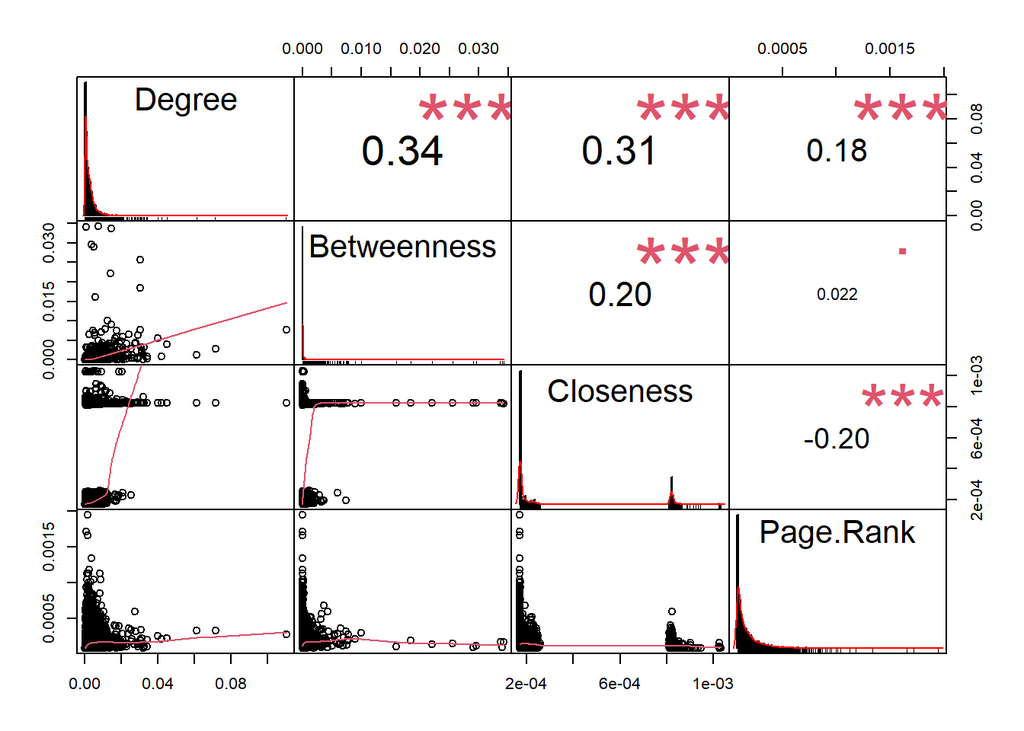

```r
results <- data.frame(Degree=dg, Betweenness=bt, Closeness=cl, `Page Rank`=pr)
chart.Correlation(results, histogram=TRUE, pch=19)
```

### Top `Betweenness`

List of artists with the largest `betweenness` centrality. This measure identifies the control of an artist on the communication between other artists in the network.

```r
top_betweenness <- head(sort(bt, decreasing=TRUE), 10)

data_artist_vertices$bt <- bt

data_artist_vertices %>%
  filter(`name` %in% names(top_betweenness)) %>%
  select(`name`, `popularity`, `count`) %>%
  arrange(factor(`name`, levels = names(top_betweenness))) %>%
  rename(`Artist name` = `name`, `Popularity` = `popularity`, `Number of songs` = `count`)
```

```
## # A tibble: 10 x 3
##    `Artist name`          Popularity `Number of songs`
##    <chr>                       <dbl>             <dbl>
##  1 Uncle Tupelo                 34.4                30
##  2 Phosphorescent               55.3                 7
##  3 Willie Nelson                31.8               515
##  4 Hoyt Axton                   35.3                 6
##  5 The Kingston Trio            17.3               134
##  6 The Byrds                    28.0               262
##  7 Sly & the Family Stone       32.3               168
##  8 Miles Davis                  22.7               864
##  9 Jefferson Airplane           31.4               146
## 10 Paul Simon                   39.5               205
```

# Comunity detection

Using https://igraph.org/r/doc/cluster_louvain.html  
More details at https://en.wikipedia.org/wiki/Louvain_method  
The different methods for finding communities, they all return a communities object: `cluster_edge_betweenness`, `cluster_fast_greedy`, `cluster_label_prop`, `cluster_leading_eigen`, `cluster_louvain`, `cluster_optimal`, `cluster_spinglass`, `cluster_walktrap.`  
In particular: * `cluster_edge_betweenness`, is slow * `cluster_spinglass`, cannot work with unconnected graph. * `cluster_optimal`, is very slow

```r
# Communities can only be calculated for undirected graphs
g_undirected <- as.undirected(g, mode='collapse', edge.attr.comb="max")
```

```r
cluster_test <- list(
  # cluster_edge_betweenness=cluster_edge_betweenness(g_undirected), # Is very slow
  cluster_fast_greedy=cluster_fast_greedy(g_undirected),
  cluster_label_prop=cluster_label_prop(g_undirected),
  cluster_leading_eigen=cluster_leading_eigen(g_undirected),
  cluster_louvain=cluster_louvain(g_undirected),
  # cluster_optimal=cluster_optimal(g_undirected) # Super slow
  # cluster_spinglass=cluster_spinglass(g), # Cannot work with unconnected graph, Invalid value
  cluster_walktrap=cluster_walktrap(g_undirected),
  walktrap.community=walktrap.community(g_undirected)
)

lapply(cluster_test, modularity)
```

```
## $cluster_fast_greedy
## [1] 0.5333517
##
## $cluster_label_prop
## [1] 0.1074397
##
## $cluster_leading_eigen
## [1] 0.4254521
##
## $cluster_louvain
## [1] 0.5523879
##
## $cluster_walktrap
## [1] 0.4686754
##
## $walktrap.community
## [1] 0.4686754
```

Best performance community calculation method, achieved with `cluster_louvain`.

```r
g_communities <- cluster_test$cluster_louvain
```

`modularity` measures how good the division is, or how separated are the different vertex types from each other. Modularity measures the strength of division of a network into modules, in this cases actor type clusters.

```r
modularity(g_communities)
```

```
## [1] 0.5523879
```

Calculates the `modularity` of a graph with respect to the given `membership` vector.

```r
modularity(g_communities, membership(g_communities))
```

```
## [1] 0.5523879
```

Number of communities of actors that exist using cluster_louvain community calculation method:

```r
length(g_communities)
```

```
## [1] 266
```

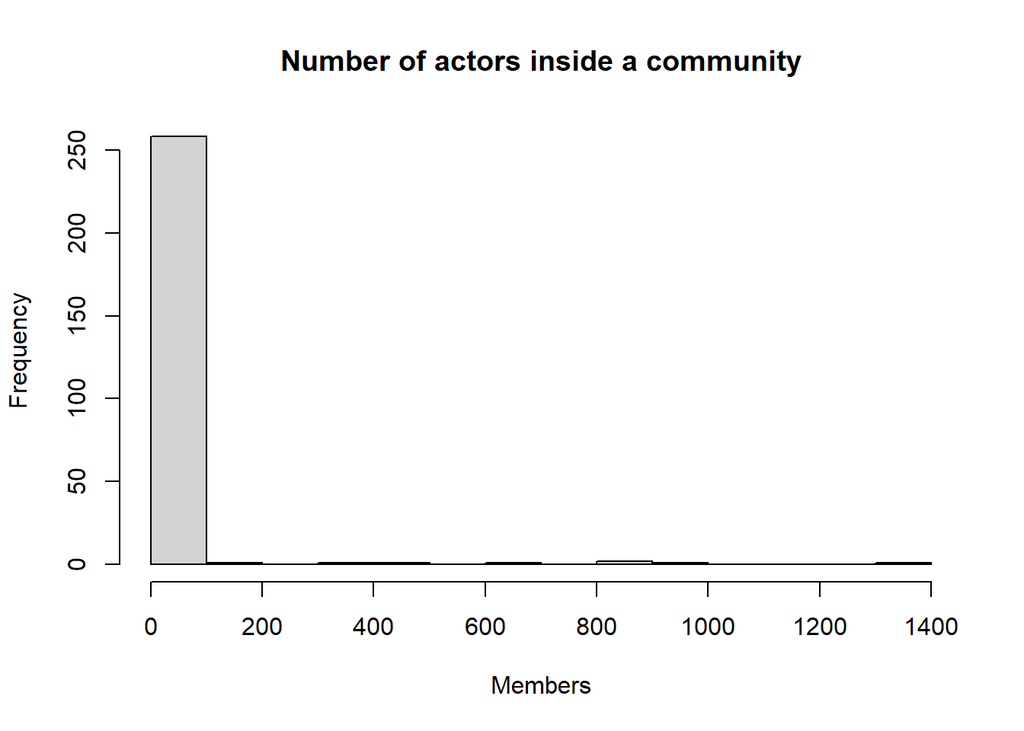

```r
hist(sizes(g_communities), main='Number of actors inside a community', xlab='Members')
```

Length per `community`

```r
x <- sapply(g_communities[], length)
summary(x)
```

```
##    Min. 1st Qu.  Median    Mean 3rd Qu.    Max.
##    1.00    1.00    1.00   22.01    1.00 1318.00
```

```r
which.max(x)
```

```
## 265
## 265
```

## Validation if the vertex labels per community makes sense

In this case it makes sense to check if the `artists` within a certain community are making sense or not.  
Makes sense, most of the `artists` are Spanish singers.

```r
g_communities[]$`66`
```

```
##  [1] "Vicente Fernández"        "Javier Solís"
##  [3] "Los Tigres del Norte"     "José Alfredo Jiménez"
##  [5] "Marco Antonio Solís"      "Lola Flores"
##  [7] "Alejandro Fernández"      "Gipsy Kings"
##  [9] "Pepe Aguilar"             "Marisela"
## [11] "Cornelio Reyna"           "Enrique Guzmán"
## [13] "Paco de Lucía"            "Los Relámpagos del Norte"
## [15] "Los Huracanes del Norte"  "Aida Cuevas"
## [17] "Los del Rio"              "Alicia Villarreal"
## [19] "Jorge Negrete"            "Jesse Cook"
## [21] "Los Alegres de Terán"     "Strunz & Farah"
## [23] "Héctor Montemayor"        "Camarón de la Isla"
```

## Filter

References: * Remove vertices - https://stackoverflow.com/questions/29784095/conditional-removing-of-vertices-based-on-attributes-in-r - https://stackoverflow.com/questions/53696798/filter-igraph-object-by-vertex-attribute-value * From - https://stackoverflow.com/questions/3305669/how-do-i-find-the-edges-of-a-vertex-using-igraph-and-r

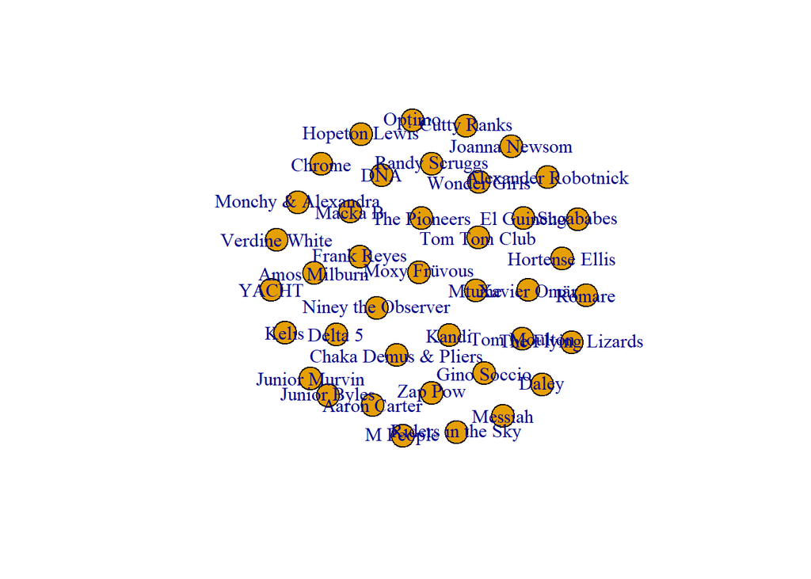

```r
g1 <- induced_subgraph(g, V(g)$danceability >= 0.85)
g2 <- induced_subgraph(g, V(g)$tempo >= 180)
plot(g1)
```

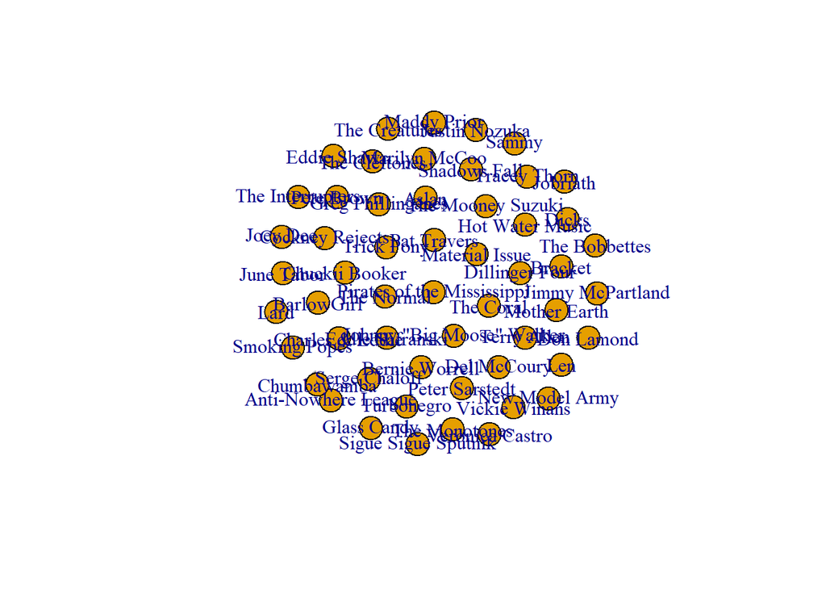

```r
plot(g2)
```

Remove edges https://stackoverflow.com/questions/25413633/igraph-in-r-how-to-select-edges-based-on-incident-vertex-attributes https://igraph.org/r/doc/subgraph.html

Subgraph creates a `subgraph` of a graph, containing only the specified vertices and all the edges among them. In this case it is possible to check the subgraph for a certain artist.

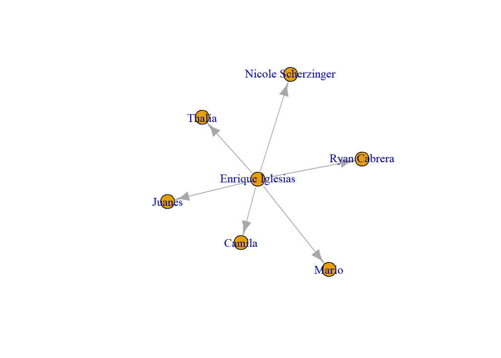

```r
filter_idx <- match("Enrique Iglesias", V(g)$name)
filter_edges <- as.numeric(E(g)[from(filter_idx)])
g1 <- subgraph.edges(g, filter_edges, delete.vertices = TRUE)

plot(g1)
```

## Topology-Ego Filter

https://stackoverflow.com/a/39992337/3780957

In this next case the desire is to find the vertices not farther than a given limit from another fixed vertex or neighbors to a certain artist. In this case first relationships.

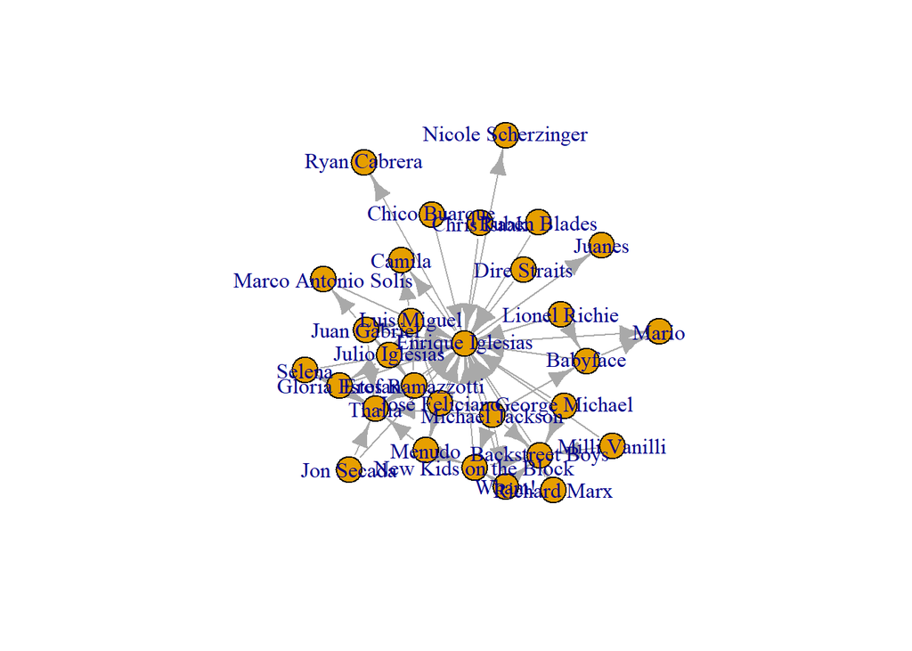

```r
# g_ego <- make_ego_graph(g, order = 1, nodes = 'Gloria Estefan', mode = "all", mindist = 0)
g_ego <- make_ego_graph(g, order = 1, nodes = 'Enrique Iglesias', mode = "all", mindist = 0)
# g_ego <- make_ego_graph(g, order = 1, nodes = 'Ricky Martin', mode = "all", mindist = 0)
# g_ego <- make_ego_graph(g, order = 1, nodes = 'Madonna', mode = "all", mindist = 0)
g_ego <- g_ego[[1]]
plot(g_ego)
```

## Evolution of `degree`

Study of the evolution of the `degree` for a single artist.  
Based on the variation of the `degree` over time for, as selected ‘Enrique Iglesias’.

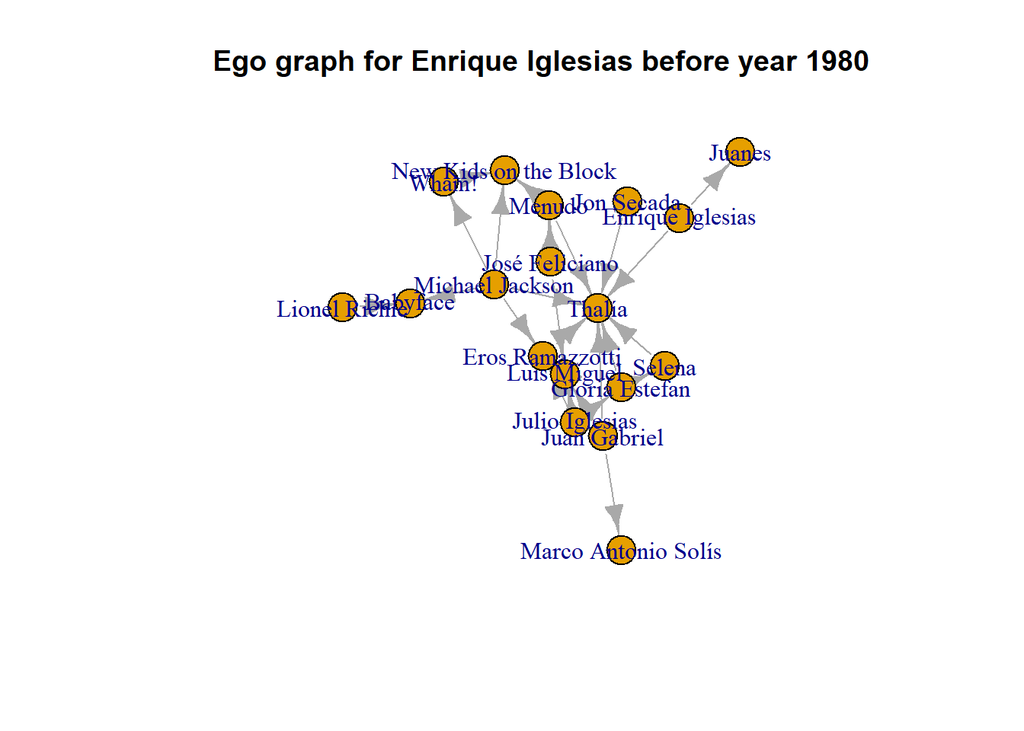

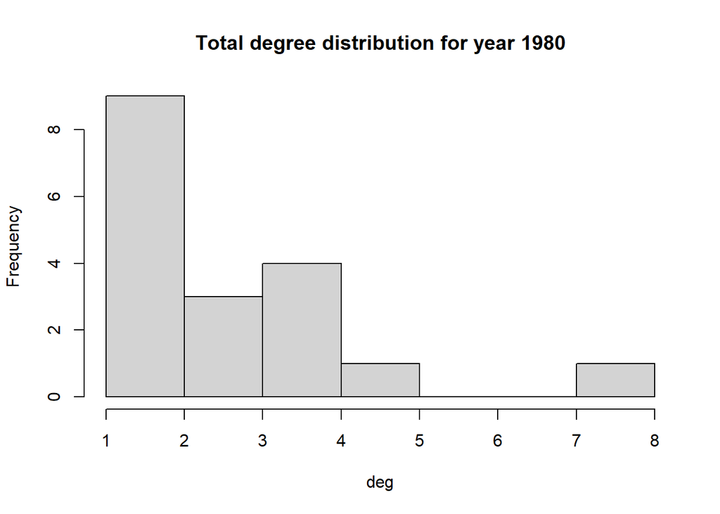

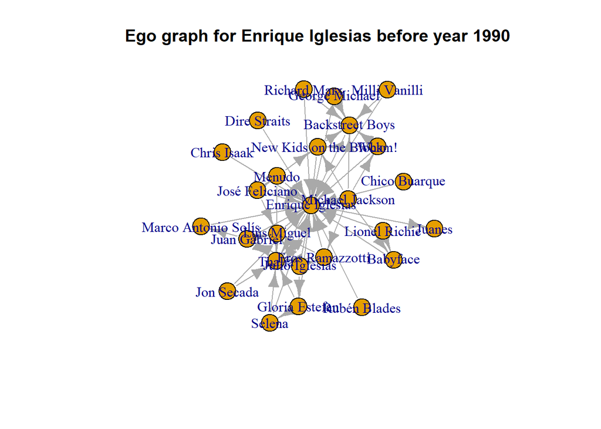

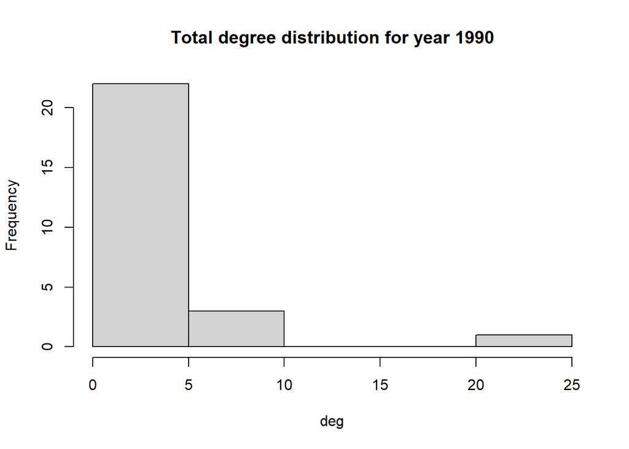

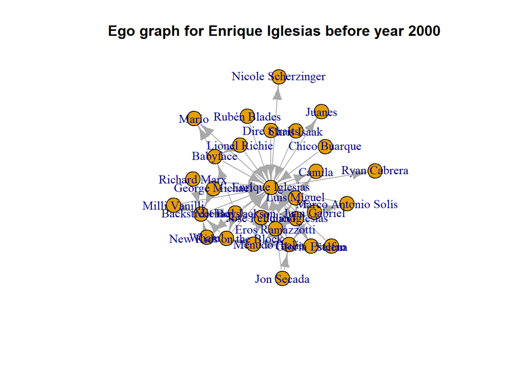

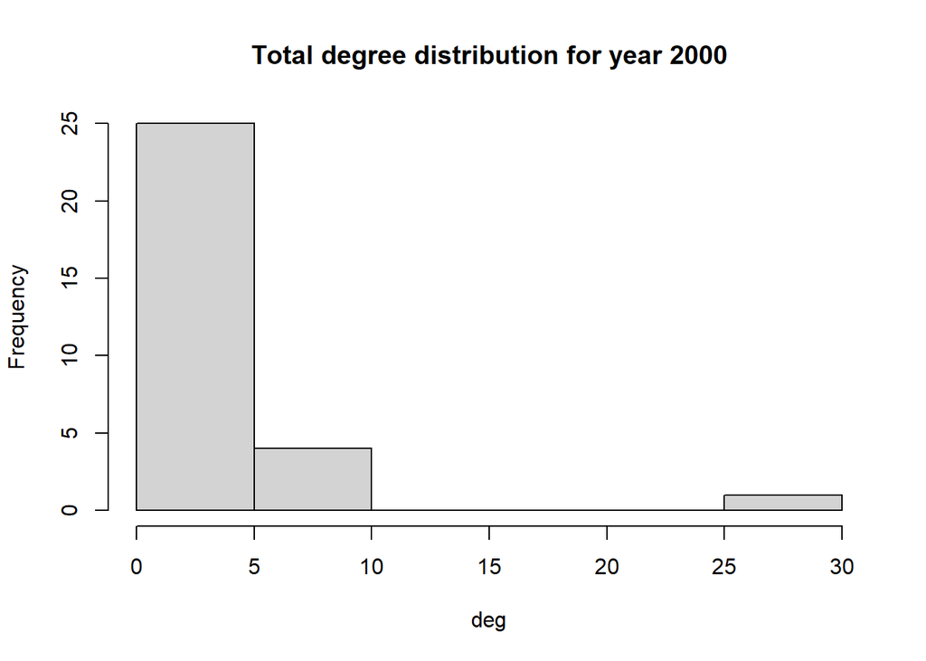

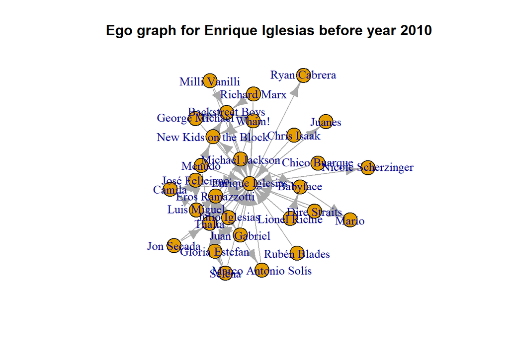

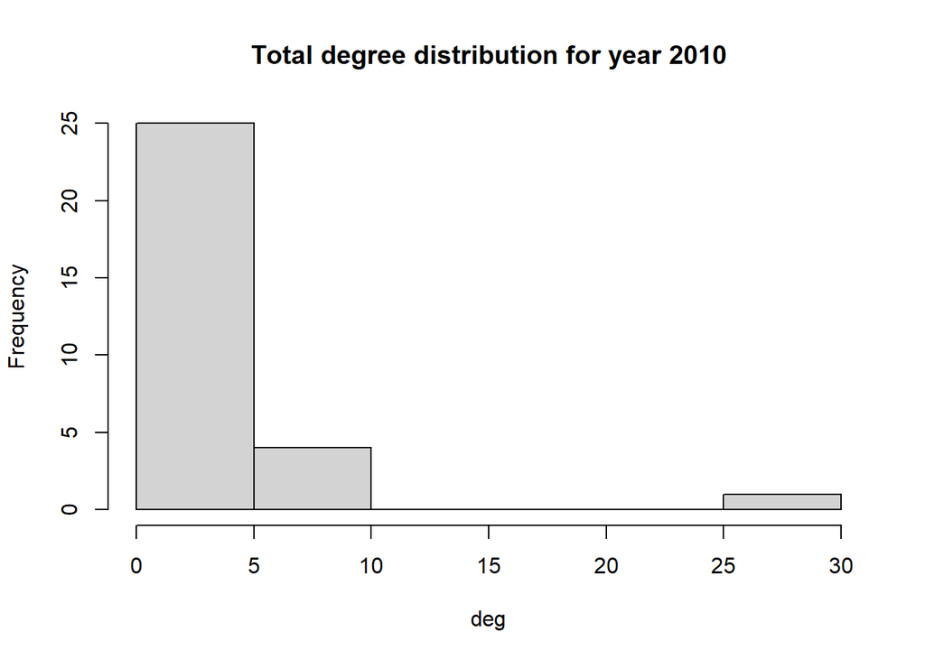

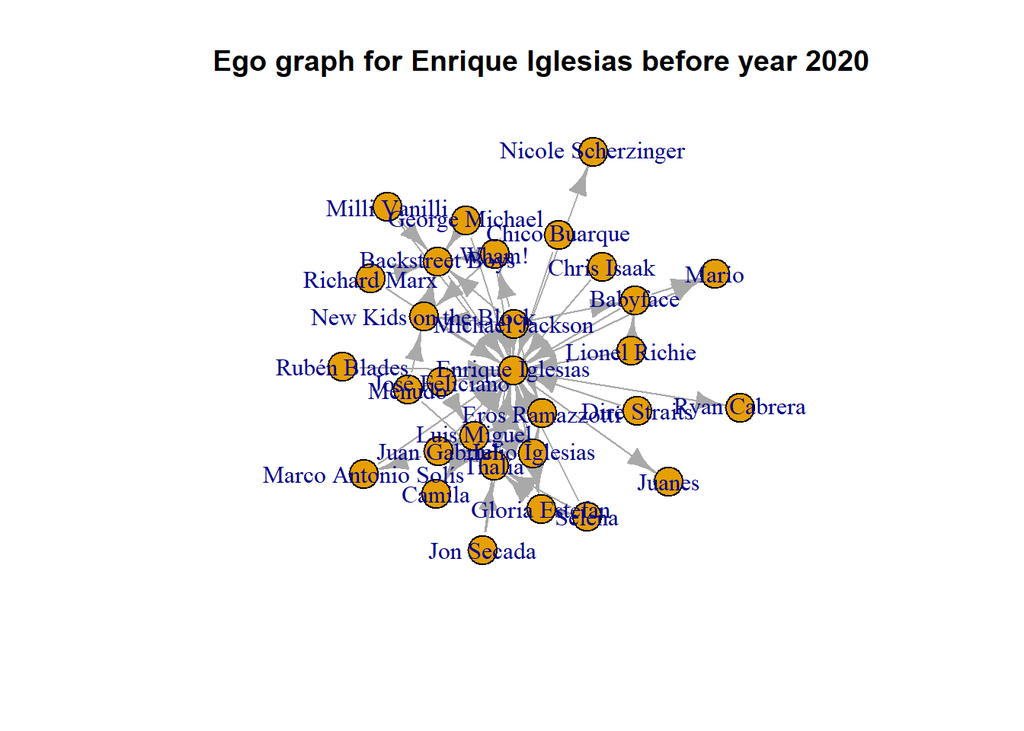

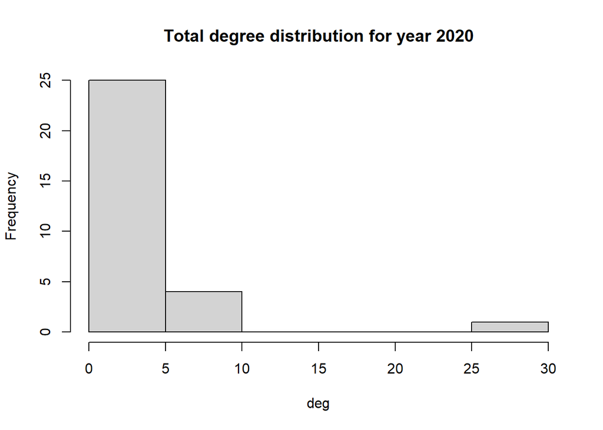

```r
artist_ <- 'Enrique Iglesias'
year_start_ <- 1980
year_end_ <- 2020

g_ego <- make_ego_graph(g, order = 1, nodes = artist_, mode = "all", mindist = 0)
g_ego <- g_ego[[1]]

artist_degree_history = data.frame(year=numeric(0), degree=numeric(0))

for (year_ in seq(year_start_, year_end_, by=10)) {
  g1 <- subgraph.edges(g_ego, E(g_ego)[E(g_ego)$follower_active_start <= year_])
  plot(g1, main=paste('Ego graph for', artist_, 'before year', year_))

  deg <- degree(g1, mode="all", loop=FALSE)
  hist(deg, main=paste('Total degree distribution for year', year_))

  artist_degree_history = artist_degree_history %>%
    add_row(year = year_, degree = as.numeric(deg[names(deg) == artist_]))

  ggplot(artist_degree_history) +
    geom_line(aes(x=year, y=degree)) +
    xlim(c(year_start_, year_end_))
}
```

### Interactive plot

https://juanitorduz.github.io/text-mining-networks-and-visualization-plebiscito-tweets/

In this case the team tried to enhance the previous representation via an interactive plot of relationships to a given artist.

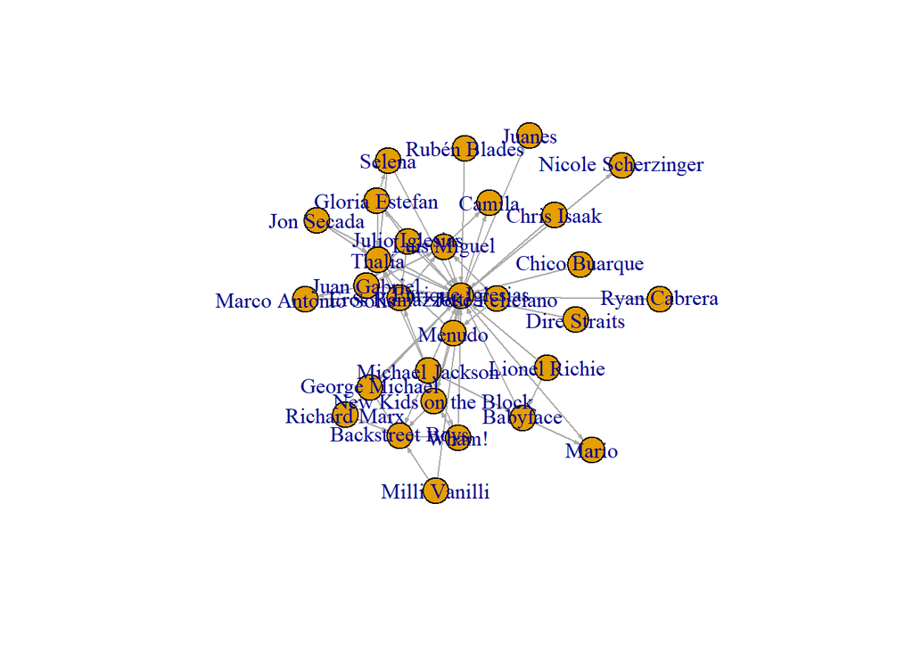

```r
plot_network_3D <- function(network, arrow=TRUE) {
  # Store the degree.
  V(network)$degree <- strength(graph = network)
  # Create networkD3 object.
  network.D3 <- igraph_to_networkD3(g = network)
  # Define node size.
  network.D3$nodes <- network.D3$node %>% mutate(Degree = V(network)$degree, Group = 1)
  # Define edges width.
  network.D3$links$Width <- 1

  forceNetwork(
    Links = network.D3$links,
    Nodes = network.D3$nodes,
    Source = 'source',
    Target = 'target',
    NodeID = 'name',
    Group = 'Group',
    opacity = 0.9,
    Value = 'Width',
    Nodesize = 'Degree',
    # We input a JavaScript function.
    linkWidth = JS("function(d) { return Math.sqrt(d.value); }"),
    fontSize = 12,
    arrows = arrow,
    zoom = TRUE,
    opacityNoHover = 1
  )
}

plot(g_ego, edge.arrow.size=.2)
```

```r
plot_network_3D(g_ego)
```

[interactive chart not shown]

## Shortest path

In this case the interest is to find the shortest path from one artist to another. The all_shortest_paths function helps retrieve visually the shortest path from one selected artist to another.

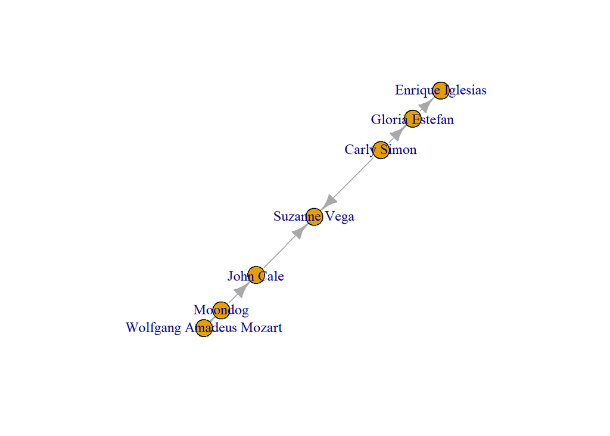

```r
short <- all_shortest_paths(g, from='Enrique Iglesias', to = 'Wolfgang Amadeus Mozart', mode = "all")
g1 <- induced_subgraph(g, short$res[[1]])
plot(g1)
```

```r
plot_network_3D(g1)
```

[interactive chart not shown]

## Color boundary for communities

https://stackoverflow.com/questions/37374355/how-can-i-plot-igraph-community-with-defined-colors

In this case for the selected artist of interest the desire is to understand its closest relationships and the communities where they belong.

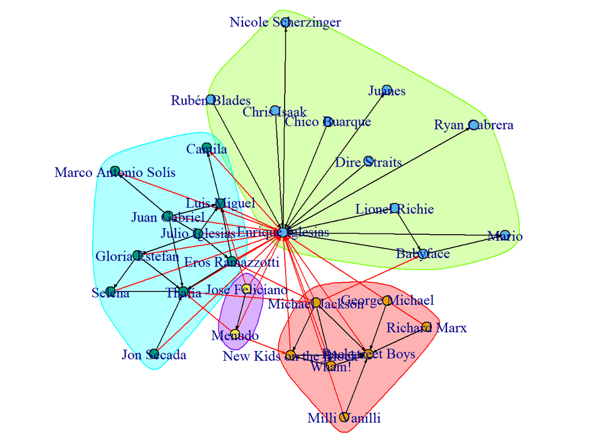

```r
g_undirected <- as.undirected(g_ego, mode='collapse', edge.attr.comb="max")
wc <- cluster_louvain(g_undirected)

layout <-layout.fruchterman.reingold(g_ego)
par(mar=c(0,0,0,0)+.1)

plot(wc, g_ego, layout=layout, vertex.size=5,  edge.arrow.size=.2)
```

# Predict edges

Based on a hierarchical random graph model.  
`predict_edges` uses a hierarchical random graph model to predict missing edges from a network. This is done by sampling hierarchical models around the optimum model, proportionally to their likelihood.

https://igraph.org/r/doc/predict_edges.html

Based on a smaller graph, centered for the selected artist it is feasible to compute the potential missing edges.

```r
hrg <- fit_hrg(g_ego)
hrg
```

```
## Hierarchical random graph, at level 3:
## g1        p=   1  Enrique Iglesias
## '- g12    p=0.11  Babyface
##    '- g19 p=   0  Marco Antonio Solís   Menudo
##                   Lionel Richie         Rubén Blades
##                   Thalía                Backstreet Boys
##                   Richard Mar           George Michael
##                   Chico Buarque         Eros Ramazzotti
##                   Selena                New Kids on the Block
##                   Ryan Cabrera          Juanes
##                   Wham!                 Michael Jackson
##                   Milli Vanilli         Gloria Estefan
##                   Jon Secada            Chris Isaak
##                   Mario                 Dire Straits
##                   Luis Miguel           Julio Iglesias
##                   Camila                José Feliciano
##                   Juan Gabriel          Nicole Scherzinger
```

```r
g_ego_predicted <- predict_edges(g_ego, hrg=hrg)
```